| [SOCR ≫](http://www.socr.umich.edu) | [DSPA ≫](http://Predictive.Space) | [Topics ≫](http://DSPA.predictive.space/) |
| --- | --- | --- |

# Data Science and Predictive Analytics (UMich HS650)

March 2018

In [previous chapters](http://dspa.predictive.space/), we used prediction accuracy to evaluate classification models. However, accurate predictions in one dataset does not necessarily imply that our model is perfect or that it will reproduce when tested on external data. We need additional metrics to evaluate the model performance to make sure it is robust, reproducible, reliable and unbiased.

In this chapter, we will discuss (1) various evaluation strategies for prediction, clustering, classification, regression, and decision trees, (2) visualization of ROC curves and performance tradeoffs, and (3) estimation of future performance, internal statistical cross-validation and bootstrap sampling.

# 1 Measuring the performance of classification methods

We can use the following three types of data to evaluate the performance of a classifier model.

- Actual class values (for supervised classification).
- Predicted class values.
- Estimated probabilities of the prediction.

We are familiar with the first two cases. The last type of validation relies on the `predict(model, test_data)` function that we have talked about in previous classification and prediction chapters ([Chapter 6-8](http://dspa.predictive.space)). Let’s revisit the model and test data we discussed in [Chapter 7](http://www.socr.umich.edu/people/dinov/courses/DSPA_notes/07_NaiveBayesianClass.html) - [Inpatient Head and Neck Cancer Medication data](https://umich.instructure.com/files/1614351/download?download_frd=1). We will demonstrate prediction probability estimation using this case-study [CaseStudy14_HeadNeck_Cancer_Medication.csv](https://umich.instructure.com/files/1614350/download?download_frd=1).

```r
hn_med<-read.csv("https://umich.instructure.com/files/1614350/download?download_frd=1", stringsAsFactors = FALSE)
hn_med$seer_stage<-factor(hn_med$seer_stage)
require(tm)
hn_med_corpus<-Corpus(VectorSource(hn_med$MEDICATION_SUMMARY))
 corpus_clean<-tm_map(hn_med_corpus, tolower)
 corpus_clean<-tm_map(corpus_clean, removePunctuation)
 corpus_clean <- tm_map(corpus_clean, stripWhitespace)
 corpus_clean <-tm_map(corpus_clean, removeNumbers)
 hn_med_dtm<-DocumentTermMatrix(corpus_clean)
 hn_med_train<-hn_med[1:562, ]
 hn_med_test<-hn_med[563:662, ]
 hn_med_dtm_train<-hn_med_dtm[1:562, ]
 hn_med_dtm_test<-hn_med_dtm[563:662, ]
 corpus_train<-corpus_clean[1:562]
 corpus_test<-corpus_clean[563:662]
 hn_med_train$stage<-hn_med_train$seer_stage %in% c(4, 5, 7)
 hn_med_train$stage<-factor(hn_med_train$stage, levels=c(F, T), labels = c("early_stage", "later_stage"))
 hn_med_test$stage<-hn_med_test$seer_stage %in% c(4, 5, 7)
 hn_med_test$stage<-factor(hn_med_test$stage, levels=c(F, T), labels = c("early_stage", "later_stage"))

convert_counts <- function(x) {
x <- ifelse(x > 0, 1, 0)
x <- factor(x, levels = c(0, 1), labels = c("No", "Yes"))
return(x)
}

 hn_med_dict<-as.character(findFreqTerms(hn_med_dtm_train, 5))
 hn_train<-DocumentTermMatrix(corpus_train, list(dictionary=hn_med_dict))
 hn_test<-DocumentTermMatrix(corpus_test, list(dictionary=hn_med_dict))
 hn_train <- apply(hn_train, MARGIN = 2, convert_counts)
 hn_test <- apply(hn_test, MARGIN = 2, convert_counts)
 library(e1071)
hn_classifier <- naiveBayes(hn_train, hn_med_train$stage)
```

```r
pred_raw<-predict(hn_classifier, hn_test, type="raw")
head(pred_raw)
```

```
##      early_stage later_stage
## [1,]   0.8812634  0.11873664
## [2,]   0.8812634  0.11873664
## [3,]   0.8425828  0.15741724
## [4,]   0.9636007  0.03639926
## [5,]   0.8654298  0.13457022
## [6,]   0.8654298  0.13457022
```

The above output includes the prediction probabilities for the first 6 rows of the data. This examples is based on [Naive Bayes classifier (naiveBayes)](http://www.socr.umich.edu/people/dinov/courses/DSPA_notes/07_NaiveBayesianClass.html#5_case_study:_head_and_neck_cancer_medication), however the same approach works for any other machine learning classification or prediction technique. The `type="raw"` indicates that the prediction call will return the *conditional a-posterior probabilities* for each class. If `type="class"` predict returns the class with *maximal probability*.

In addition, we can report the predicted probability with the outputs of the Naive Bayesian decision-support system (`hn_classifier <- naiveBayes(hn_train, hn_med_train$stage)`):

```r
pred_nb<-predict(hn_classifier, hn_test)
head(stats::ftable(pred_nb))
```

```
##
##  "pred_nb" "early_stage" "later_stage"
##
##                       96             4
```

The general `predict()` method automatically subclasses to the specific `predict.naiveBayes(object, newdata, type = c("class", "raw"), threshold = 0.001, ...)` call where `type="raw"` and `type = "class"` specify the output as the conditional a-posterior probabilities for each class or the class with maximal probability, respectively. Back in [Chapter 8](http://www.socr.umich.edu/people/dinov/courses/DSPA_notes/08_DecisionTreeClass.html) where we discussed the `C5.0` and the `randomForest` classifiers to predict the chronic disease score in a another case-study [Quality of Life (QoL)](https://umich.instructure.com/files/481332/download?download_frd=1).

Below are the (probability) results of the `C5.0` classification tree model prediction:

```r
pred_prob<-predict(qol_model, qol_test, type="prob")
head(pred_prob)
```

```
##    minor_disease severe_disease
## 10     0.1979698      0.8020302
## 12     0.1979698      0.8020302
## 26     0.3468705      0.6531295
## 37     0.1263975      0.8736025
## 41     0.7290209      0.2709791
## 43     0.3163673      0.6836327
```

These can be contrasted against the `C5.0` tree classification label results:

```r
pred_tree<-predict(qol_model, qol_test)
head(pred_tree); head(stats::ftable(pred_tree))
```

```
## [1] severe_disease severe_disease severe_disease severe_disease
## [5] minor_disease  severe_disease
## Levels: minor_disease severe_disease
```

```
##
##  "pred_tree" "minor_disease" "severe_disease"
##
##                          238              205
```

The same complementary types of outputs can be reported for most machine learning classification and prediction approaches.

# 2 Evaluation strategies

In [Chapter 6](http://www.socr.umich.edu/people/dinov/courses/DSPA_notes/06_LazyLearning_kNN.html), we saw an attempt to categorize the supervised classification and unsupervised clustering methods. Similarly, the *table* below summarizes the basic types of evaluation and validation strategies for different forecasting, prediction, ensembling, and clustering techniques. [(Internal) Statistical Cross Validation](http://www.socr.umich.edu/people/dinov/courses/DSPA_notes/20_PredictionCrossValidation.html) or external validation should always be applied to ensure reliability and reproducibility of the results. The SciKit [clustering performance evaluation](http://scikit-learn.org/stable/modules/clustering.html#clustering-performance-evaluation) and [Classification metrics](http://scikit-learn.org/stable/modules/classes.html#module-sklearn.metrics) sections provide details about many alternative techniques and metrics for performance evaluation of clustering and classification methods.

| Inference | Outcome | Evaluation Metrics | R functions |
| --- | --- | --- | --- |
| Classification & Prediction | Binary | Accuracy, Sensitivity, Specificity, PPV/Precision, NPV/Recall, LOR | `caret::confusionMatrix`, `gmodels::CrossTable`, `cluster::silhouette` |
| Classification & Prediction | Categorical | Accuracy, Sensitivity/Specificity, PPV, NPV, LOR, Silhouette Coefficient | `caret::confusionMatrix`, `gmodels::CrossTable`, `cluster::silhouette` |
| Regression Modeling | Real Quantitative | correlation coefficient, $R^2$, RMSE, Mutual Information, Homogeneity and Completeness Scores | `cor`, `metrics::mse` |

## 2.1 Binary outcomes

More details about binary test assessment is available on the [Scientific Methods for Health Sciences (SMHS) EBook site](http://wiki.socr.umich.edu/index.php/SMHS_IntroEpi#Screening). The table below summarizes the key measures commonly used to evaluate the performance of binary tests, classifiers, or predictions.

|  |  | **Actual Condition** |  | **Test Interpretation** |  |  |
| --- | --- | --- | --- | --- | --- | --- |
|  |  | **Absent ($H_0$ is true)** | **Present ($H_1$ is true)** |  |  |  |
| **Test Result** | Negative (fail to reject $H_0$) | **TN** Condition absent + Negative result = True (accurate) Negative | **FN** *Condition present + Negative result = False (invalid) Negative **Type II error** (proportional to $\beta$)* |  | $NPV$ $=\frac{TN}{TN+FN}$ |  |
|  | Positive (reject $H_0$) | **FP** Condition absent + Positive result = False Positive **Type I error** ($\alpha$) | **TP** Condition Present + Positive result = True Positive | $PPV=Precision$ $=\frac{TP}{TP+FP}$ |  |  |
| **Test Interpretation** | $Power =1-\beta$ $= 1-\frac{FN}{FN+TP}$ | $Specificity=\frac{TN}{TN+FP}$ | $Power=Recall=Sensitivity$ $=\frac{TP}{TP+FN}$ | $LOR=\ln\left (\frac{TN\times TP}{FP\times FN}\right )$ |  |  |

See also [SMHS EBook, Power, Sensitivity and Specificity section](http://wiki.socr.umich.edu/index.php/SMHS_PowerSensitivitySpecificity).

## 2.2 Confusion matrices

We talked about this type of matrix in [Chapter 8](http://www.socr.umich.edu/people/dinov/courses/DSPA_notes/08_DecisionTreeClass.html). For binary classes, there will be a $2\times 2$ matrix. Each of the cells have a specific meaning.

Graph $2\times 2$ table:

cross table

|  | predict_T | predict_F |
| --- | --- | --- |
| TRUE | TP | TN |
| FALSE | FP | FN |

- **True Positive**(TP): Number of observations that correctly classified as “yes” or “success”.
- **True Negative**(TN): Number of observations that correctly classified as “no” or “failure”.
- **False Positive**(FP): Number of observations that incorrectly classified as “yes” or “success”.
- **False Negative**(FN): Number of observations that incorrectly classified as “no” or “failure”.

**Using confusion matrices to measure performance**

The way we calculate accuracy using these four cells is summarized by the following formula:
$$accuracy=\frac{TP+TN}{TP+TN+FP+FN}=\frac{TP+TN}{\text{Total number of observations}}$$
On the other hand, the error rate, or proportion of incorrectly classified observations is calculated using:
$$error rate=\frac{FP+FN}{TP+TN+FP+FN}==\frac{FP+FN}{\text{Total number of observations}}=1-accuracy$$
If we look at the numerator and denominator carefully, we can see that the error rate and accuracy add up to 1. Therefore, a 95% accuracy means 5% error rate.

In R, we have multiple ways to obtain confusion table. The simplest way would be `table()`. For example, in [Chapter 7](http://www.socr.umich.edu/people/dinov/courses/DSPA_notes/07_NaiveBayesianClass.html), to get a plain $2\times 2$ table reporting the agreement between the real clinical cancer labels and their machine learning predicted counterparts, we used:

```r
hn_test_pred<-predict(hn_classifier, hn_test)
table(hn_test_pred, hn_med_test$stage)
```

```
##
## hn_test_pred  early_stage later_stage
##   early_stage          73          23
##   later_stage           4           0
```

The reason we sometimes use the `gmodels::CrossTable()` function, e.g., see [Chapter 7](http://www.socr.umich.edu/people/dinov/courses/DSPA_notes/07_NaiveBayesianClass.html), is because it reports additional information about the model performance.

```r
library(gmodels)
CrossTable(hn_test_pred, hn_med_test$stage)
```

```
##
##
##    Cell Contents
## |-------------------------|
## |                       N |
## | Chi-square contribution |
## |           N / Row Total |
## |           N / Col Total |
## |         N / Table Total |
## |-------------------------|
##
##
## Total Observations in Table:  100
##
##
##              | hn_med_test$stage
## hn_test_pred | early_stage | later_stage |   Row Total |
## -------------|-------------|-------------|-------------|
##  early_stage |          73 |          23 |          96 |
##              |       0.011 |       0.038 |             |
##              |       0.760 |       0.240 |       0.960 |
##              |       0.948 |       1.000 |             |
##              |       0.730 |       0.230 |             |
## -------------|-------------|-------------|-------------|
##  later_stage |           4 |           0 |           4 |
##              |       0.275 |       0.920 |             |
##              |       1.000 |       0.000 |       0.040 |
##              |       0.052 |       0.000 |             |
##              |       0.040 |       0.000 |             |
## -------------|-------------|-------------|-------------|
## Column Total |          77 |          23 |         100 |
##              |       0.770 |       0.230 |             |
## -------------|-------------|-------------|-------------|
##
##
```

The second entry in each cell of the *crossTable* table reports the Chi-square contribution. This uses the standard [Chi-Square formula](http://wiki.socr.umich.edu/index.php/AP_Statistics_Curriculum_2007_Contingency_Indep) for computing relative discrepancy between *observed* and *expected* counts. For instance, the Chi-square contribution of *cell(1,1)*, (`hn_med_test$stage=early_stage` and `hn_test_pred=early_stage`), can be computed as follows from the $\frac{(Observed-Expected)^2}{Expected}$ formula. Assuming independence between the rows and columns (i.e., random classification), the *expected cell(1,1) value* is computed as the product of the corresponding row (96) and column (77) marginal counts, $\frac{96\times 77}{100}$. Thus the Chi-square value for cell(1,1) is:

$$\text{Chi-square cell(1,1)} = \frac{(Observed-Expected)^2}{Expected}=$$
$$=\frac{\left (73-\frac{96\times 77}{100}\right ) ^2}{\frac{96\times 77}{100}}=0.01145022.$$

Note that each cell Chi-square value represents one of the four (in this case) components of the Chi-square test-statistics, which tries to answer the question if there is no association between observed and predicted class labels. That is, under the null-hypothesis there is no association between actual and observed counts for each level of the factor variable, which allows us to quantify whether the derived classification jibes with the real class annotations (labels). The aggregate sum of all Chi-square values represents the $\chi_o^2 = \displaystyle\sum_{all-categories}{(O-E)^2 \over E} \sim \chi_{(df)}^2$ statistics, where $df = (\# rows - 1)\times (\# columns - 1)$.

Using either table (CrossTable, confusionMatrix), we can calculate accuracy and error rate by hand.

```r
accuracy<-(73+0)/100
accuracy
```

```
## [1] 0.73
```

```r
error_rate<-(23+4)/100
error_rate
```

```
## [1] 0.27
```

```r
1-accuracy
```

```
## [1] 0.27
```

For matrices that are larger than $2\times 2$, all diagonal elements count the observations that are correctly classified and the off-diagonal elements represent incorrectly labeled cases.

## 2.3 Other measures of performance beyond accuracy

So far we discussed two performance methods - `table()` and `CrossTable()`. A third function is `caret::confusionMatrix()` which provides the easiest way to report model performance. Notice that the first argument is an *actual vector of the labels*, i.e., $Test\_Y$ and the second argument, of the same length, represents the *vector of predicted labels*.

This example was presented as the first case-study in [Chapter 8](http://www.socr.umich.edu/people/dinov/courses/DSPA_notes/08_DecisionTreeClass.html).

```r
library(caret)
qol_pred<-predict(qol_model, qol_test)
confusionMatrix(table(qol_pred, qol_test$cd), positive="severe_disease")
```

```
## Confusion Matrix and Statistics
##
##
## qol_pred         minor_disease severe_disease
##   minor_disease            149             89
##   severe_disease            74            131
##
##                Accuracy : 0.6321
##                  95% CI : (0.5853, 0.6771)
##     No Information Rate : 0.5034
##     P-Value [Acc > NIR] : 3.317e-08
##
##                   Kappa : 0.2637
##  Mcnemar's Test P-Value : 0.2728
##
##             Sensitivity : 0.5955
##             Specificity : 0.6682
##          Pos Pred Value : 0.6390
##          Neg Pred Value : 0.6261
##              Prevalence : 0.4966
##          Detection Rate : 0.2957
##    Detection Prevalence : 0.4628
##       Balanced Accuracy : 0.6318
##
##        'Positive' Class : severe_disease
##
```

### 2.3.1 Silhouette coefficient

In [Chapter 12](http://www.socr.umich.edu/people/dinov/courses/DSPA_notes/12_kMeans_Clustering.html#2_silhouette_plots) we already saw the *Silhouette coefficient*, which captures the shape of the clustering boundaries. It is a function of the *intracluster distance* of a sample in the dataset ($i$). Suppose:

- $d_i$ is the average dissimilarity of point $i$ with all other data points within its cluster. Then, $d_i$ captures the quality of the assignment of $i$ to its current class label. Smaller or larger $d_i$ values suggest better or worse overall assignment for $i$ to its cluster, respectively. The average dissimilarity of $i$ to a cluster $C$ is the average distance between $i$ and all points in the cluster of points labeled $C$.
- $l_i$ is the lowest average dissimilarity of point $i$ to any other cluster, that $i$ is not a member of. The cluster corresponding to $l_i$, the lowest average dissimilarity, is called the $i$ neighboring cluster, as it is the next best fit cluster for $i$.

Then, the *Silhouette coefficient* for a sample point $i$ is:

$$-1\leq Silhouette(i)=\frac{l_i-d_i}{\max(l_i,d_i)} \leq 1.$$
For interpreting the Silhouette of point $i$, we use:

$$Silhouette(i) \approx
\begin{cases}
-1 & \text{sample } i \text{ is closer to a neighboring cluster} \\
0 & \text {the sample } i \text{ is near the border of its cluster, i.e., } i \text{ represents the closest point in its cluster to the rest of the dataset clusters} \\
1 & \text {the sample } i \text{ is near the center of its cluster}
\end{cases}.$$

The *mean Silhouette value* represents the arithmetic average of all Silhouette coefficients (either within a cluster, or overall) and represents the quality of the cluster (clustering). High mean Silhouette corresponds to compact clustering (dense and separated clusters), whereas low values represent more diffused clusters. The Silhouette value is useful when the number of predicted clusters is smaller than the number of samples.

### 2.3.2 The kappa ( $\kappa$ ) statistic

The Kappa statistic was [originally developed to measure the reliability between two human raters](http://wiki.socr.umich.edu/index.php/SMHS_ReliabilityValidity). It can be harnessed in machine learning applications to compare the accuracy of a classifier, where `one rater` represents the ground truth (for labeled data, these are the actual values of each instance) and the `second rater` represents the results of the automated machine learning classifier. The order of listing the **raters** is irrelevant.

Kappa statistic measures the **possibility of a correct prediction by chance alone** and answers the question of *How much better is the agreement (between the ground truth and the machine learning prediction) than would be expected by chance alone?* Its value is between $0$ and $1$. When $\kappa=1$, we have a perfect agreement between a **computed** prediction (typically the result of a model-based or model-free technique forecasting an outcome of interest) and an **expected** prediction (typically random, by-chance, prediction). A common interpretation of the Kappa statistics includes:

- Poor agreement: less than 0.20
- Fair agreement: 0.20-0.40
- Moderate agreement: 0.40-0.60
- Good agreement: 0.60-0.80
- Very good agreement: 0.80-1

In the above `confusionMatrix` output, we have a fair agreement. For different problems, we may have different interpretations of Kappa statistics.

To understand Kappa statistic better, let’s look at its formula:

$$kappa=\frac{P(a)-P(e)}{1-P(e)}.$$

`P(a)` and `P(e)` simply denote probability of **actual** and **expected** agreement between the classifier and true values. Recall that previously we defined a chronic-disease binary outcome `qol$cd<-qol$CHRONICDISEASESCORE>1.497`. Let’s use the Quality of Life `cd` prediction (qol_pred) for computing the kappa statistics by hand.

```r
table(qol_pred, qol_test$cd)
```

```
##
## qol_pred         minor_disease severe_disease
##   minor_disease            149             89
##   severe_disease            74            131
```

According to above table, actual agreement is the accuracy:

```r
p_a<-(149+131)/(149+89+74+131)
p_a
```

```
## [1] 0.6320542
```

```r
confusionMatrix(table(qol_pred, qol_test$cd), positive="severe_disease")$overall[1] # report official Accuracy
```

```
##  Accuracy
## 0.6320542
```

The manually and automatically computed accuracies coincide (0.6321).

In our case:

```r
p_e_minor <- ((149+74)/(149+89+74+131))*((149+89)/(149+89+74+131))
p_e_severe <- ((131+74)/(149+89+74+131)) * ((89+131)/(149+89+74+131))
p_e <- p_e_minor + p_e_severe
p_e
```

```
## [1] 0.5002522
```

Plug `p_a` and `p_e` into the formula to get `Kappa`:

```r
kappa <- round((p_a-p_e)/(1-p_e), 2)
kappa
```

```
## [1] 0.26
```

```r
round(confusionMatrix(table(qol_pred, qol_test$cd), positive="severe_disease")$overall[2], 2) # report official Kappa
```

```
## Kappa
##  0.26
```

We get a similar value in the `confusionTable()` output. A more straight forward way of getting the Kappa statistics is by using `Kappa()` function in the `vcd` package.

```r
# install.packages(vcd)
library(vcd)
Kappa(table(qol_pred, qol_test$cd))
```

```
##             value     ASE     z  Pr(>|z|)
## Unweighted 0.2637 0.04573 5.767 8.071e-09
## Weighted   0.2637 0.04573 5.767 8.071e-09
```

The combination of `Kappa()` and `table` function yields a $2\times 4$ matrix. The *Kappa statistic* is under the unweighted value.

Generally speaking, predicting a severe disease outcome is a more critical problem than predicting a mild disease state. Thus, weighted Kappa is also useful. We give the severe disease a higher weight. The Kappa test result is not acceptable since the classifier may make too many mistakes for the severe disease cases. The Kappa value is $0.26374$. Notice that the range of weighted Kappa may exceed [0,1].

```r
Kappa(table(qol_pred, qol_test$cd),weights = matrix(c(1,10,1,10),nrow=2))
```

```
##              value     ASE     z  Pr(>|z|)
## Unweighted 0.26374 0.04573 5.767 8.071e-09
## Weighted   0.06818 0.04009 1.701 8.898e-02
```

```r
table(qol_pred, qol_test$cd)
```

```
##
## qol_pred         minor_disease severe_disease
##   minor_disease            149             89
##   severe_disease            74            131
```

#### 2.3.2.1 Summary of the Kappa score for calculating prediction accuracy

Kappa compares an **Observed classification accuracy** (output of our ML classifier) with an **Expected classification accuracy** (corresponding to random chance classification). It may be used to evaluate single classifiers and/or to compare among a set of different classifiers. It takes into account random chance (agreement with a random classifier). That makes **Kappa** more meaningful than simply using the **accuracy** as a single quality metric. For instance, the interpretation of an `Observed Accuracy of 80%` is **relative** to the `Expected Accuracy`. `Observed Accuracy of 80%` is more impactful for an `Expected Accuracy of 50%` compared to `Expected Accuracy of 75%`.

#### 2.3.2.2 Computation of Observed Accuracy and Expected Accuracy

Consider the following example of a `classifier` generating the following `confusion matrix`. Columns represent the **true labels** and rows represent the **classifier-derived labels** for this binary prediction example.

| Class | True | False | Total |
| --- | --- | --- | --- |
| T | 50 | 35 | 85 |
| F | 25 | 40 | 65 |
| Total | 75 | 75 | 150 |

In this example, there are a total of 150 observations ($50+35+25+40$). In reality, 75 are labeled as **True** ($50 + 25$) and another 75 are labeled as **False** ($35 + 40$). The classifier labeled 85 as **True** ($50 + 35$) and the other 65 as **False** ($25 + 40$).

- Observed Accuracy (OA) is the `proportion of instances` that were classified correctly throughout the entire confusion matrix:
  $$OA = \frac{50 + 40}{150} = 0.6$$
- Expected Accuracy (EA) is the accuracy that any random classifier would be expected to achieve based on the given confusion matrix. EA is the `proportion of instances` of each class (**True** and **False**), along with the number of instances that the automated classifier agreed with the ground truth label. The EA is calculated by multiplying the marginal frequencies of **True** for the true-state and the machine classified instances, and dividing by the total number of instances. The marginal frequency of **True** for the **true-state** is 75 ($50 + 25$) and for the corresponding ML classifier is 85 ($50 + 35$). Then, the expected accuracy for the **True** outcome is:
  $$EA(True) = \frac{75 \times 85}{150} = 42.5$$

We similarly compute the $EA(False)$ for the second, **False**, outcome, by using the marginal frequencies for the true-state ($(False|true-state) = 75 = 50 + 25$) and the ML classifier $(False|classifier) = 65 (40+25)$. Then, the expected accuracy for the **True** outcome is:

$$EA(False) = \frac{75 \times 65}{150} = 32.5$$

Finally, the $EA = \frac{EA(True) + EA(False)}{150}$

$$Expected Accuracy (EA) = \frac{42.5 + 32.5}{150} = 0.5$$

Note that $EA = 0.5$ whenever the `true-state` binary classification is balanced (in reality, the frequencies of **True** and **False** are equal, in our case 75).

The calculation of the **kappa statistic** relies on $OA=0.6$ and $EA=0.5$:
$$(Kappa)\text{ } \kappa = \frac{OA - EA}{1 - EA} = \frac{0.6-0.5}{1-0.5}=0.2.$$

### 2.3.3 Sensitivity and specificity

Take a closer look at the `confusionMatrix()` output where we can find two important statistics - “sensitivity” and “specificity”.

Sensitivity or true positive rate measures the proportion of “success” observations that are correctly classified.
$$sensitivity=\frac{TP}{TP+FN}.$$
Notice $TP+FN$ are the total number of true “success” observations.

On the other hand, specificity or true negative rate measures the proportion of “failure” observations that are correctly classified.
$$sensitivity=\frac{TN}{TN+FP}.$$
Accordingly, $TN+FP$ are the total number of true “failure” observations.

In the QoL data, considering “severe_disease” as “success” and using the `table()` output we can manually compute the *sensitivity* and *specificity*, as well as *precision* and *recall* (below):

```r
sens<-131/(131+89)
sens
```

```
## [1] 0.5954545
```

```r
spec<-149/(149+74)
spec
```

```
## [1] 0.6681614
```

Another R package `caret` also provides functions to directly calculate the sensitivity and specificity.

```r
library(caret)
sensitivity(qol_pred, qol_test$cd, positive="severe_disease")
```

```
## [1] 0.5954545
```

```r
# specificity(qol_pred, qol_test$cd)
confusionMatrix(table(qol_pred, qol_test$cd), positive="severe_disease")$byClass[1] # another way to report the sensitivity
```

```
## Sensitivity
##   0.5954545
```

```r
# confusionMatrix(table(qol_pred, qol_test$cd), positive="severe_disease")$byClass[2] # another way to report the specificity
```

Sensitivity and specificity both range from 0 to 1. For either measure, a values of 1 imply that the positive and negative predictions are very accurate. However, simultaneously high sensitivity and specificity may not be attainable in real world situations. There is a tradeoff between sensitivity and specificity. To compromise, some studies loosen the demands on one and focus on achieving high values on the other.

### 2.3.4 Precision and recall

```r
prec<-131/(131+74)
prec
```

```
## [1] 0.6390244
```

```r
recall<-131/(131+89)
recall
```

```
## [1] 0.5954545
```

Another way to obtain *precision* would be `posPredValue()` under `caret` package. Remember to specify which one is the “success” class.

```r
posPredValue(qol_pred, qol_test$cd, positive="severe_disease")
```

```
## [1] 0.6390244
```

From the definitions of **precision** and **recall**, we can derive the type 1 error and type 2 errors as follow:

$$error_1 = 1- Precision = \frac{FP}{TP+FP}.$$

Thus, we can compute the type 1 error ($0.36$) and type 2 error ($0.40$).

```r
error1<-74/(131+74)
error2<-89/(131+89)
error1; error2
```

```
## [1] 0.3609756
```

```
## [1] 0.4045455
```

### 2.3.5 The F-measure

The F-measure, or F1-score, combines precision and recall using the [harmonic mean](http://wiki.socr.umich.edu/index.php/SMHS_CenterSpreadShape#Harmonic_Mean) assuming equal weights. High F1-score means high precision and high recall. This is a convenient way of measuring model performances and comparing models.
$$F1=\frac{2\times precision\times recall}{recall+precision}=\frac{2\times TP}{2\times TP+FP+FN}$$
If calculating the F1-score by hand, using the Quality of Life prediction:

```r
f1<-(2*prec*recall)/(prec+recall)
f1
```

```
## [1] 0.6164706
```

The direct calculations of the F1-statistics can be obtained using `caret`:

```r
precision <- posPredValue(qol_pred, qol_test$cd, positive="severe_disease")
recall <- sensitivity(qol_pred, qol_test$cd, positive="severe_disease")
F1 <- (2 * precision * recall) / (precision + recall); F1
```

```
## [1] 0.6164706
```

# 3 Visualizing performance tradeoffs (ROC Curve)

Another choice for evaluating classifiers’ performance is by graphs rather than statistics. Graphs are usually more comprehensive than single statistics.

The R package `ROCR` provides user-friendly functions for visualizing model performance. Details could be find on the [ROCR website](http://rocr.bioinf.mpi-sb.mpg.de).

Here we evaluate the model performance for the Quality of Life case study in [Chapter 8](http://www.socr.umich.edu/people/dinov/courses/DSPA_notes/08_DecisionTreeClass.html).

```r
# install.packages("ROCR")
library(ROCR)
pred<-ROCR::prediction(predictions=pred_prob[, 2], labels=qol_test$cd)
# avoid naming collision (ROCR::prediction), as
# there is another prediction function in the neuralnet package.
```

`pred_prob[, 2]` is the probability of classifying each observation as “severe_disease”. The above code saved all the model prediction information into the object `pred`.

[Receiver Operating Characteristic (ROC)](http://wiki.socr.umich.edu/index.php/SMHS_ROC) curves are often used for examine the trade-off between detecting true positives and avoiding the false positives.

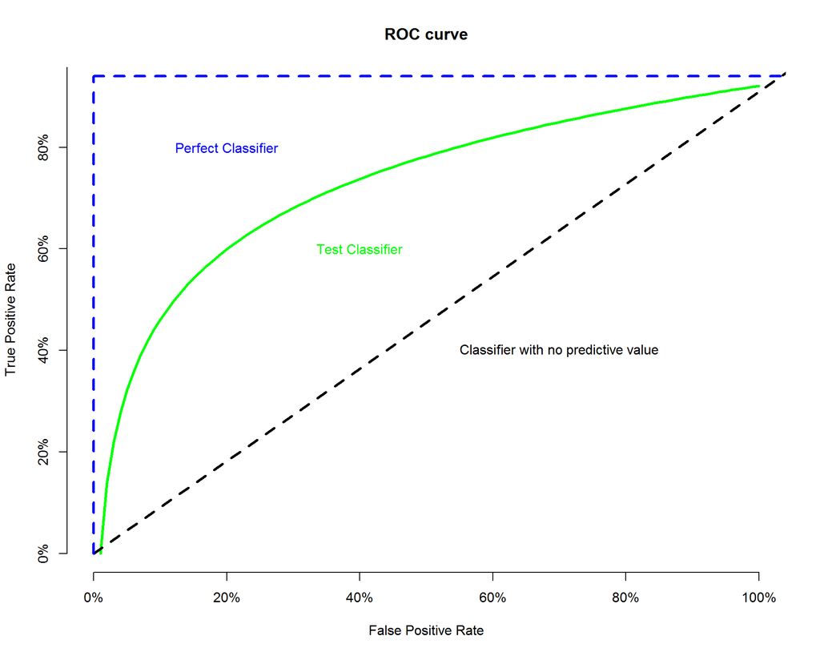

```r
curve(log(x), from=0, to=100, xlab="False Positive Rate", ylab="True Positive Rate", main="ROC curve", col="green", lwd=3, axes=F)
Axis(side=1, at=c(0, 20, 40, 60, 80, 100), labels = c("0%", "20%", "40%", "60%", "80%", "100%"))
Axis(side=2, at=0:5, labels = c("0%", "20%", "40%", "60%", "80%", "100%"))
segments(0, 0, 110, 5, lty=2, lwd=3)
segments(0, 0, 0, 4.7, lty=2, lwd=3, col="blue")
segments(0, 4.7, 107, 4.7, lty=2, lwd=3, col="blue")
text(20, 4, col="blue", labels = "Perfect Classifier")
text(40, 3, col="green", labels = "Test Classifier")
text(70, 2, col="black", labels= "Classifier with no predictive value")
```

The blue line in the above graph represents the perfect classifier where we have 0% false positive and 100% true positive. The middle green line represents a test classifier. Most of our classifiers trained by real data will look like this. The black diagonal line illustrates a classifier with no predictive value. We can see that it has same true positive rate and false positive rate. Thus, it cannot distinguish between the two states.

Classifiers with high true positive values have ROC curves near the (blue) *perfect classifier* curve. Thus, we measure the area under the ROC curve (abbreviated as AUC) as a proxy of the classifier performance. To do this, we have to change the scale of the graph above. Mapping 100% to 1, we have a $1\times 1$ square. The area under perfect classifier would be 1 and area under classifier with no predictive value being 0.5. Then, 1 and 0.5 will be the upper and lower limits for our model ROC curve. For model ROC curves, the typical interpretation of the area under curve (AUC) includes:

- Outstanding: 0.9-1.0
- Excellent/good: 0.8-0.9
- Acceptable/fair: 0.7-0.8
- Poor: 0.6-0.7
- No discrimination: 0.5-0.6

Note that this rating system is somewhat subjective. We can use the `ROCR` package to draw ROC curves.

```r
roc<-performance(pred, measure="tpr", x.measure="fpr")
```

We can specify a “performance” object by providing `"tpr"` (True positive rate) and `"fpr"` (False positive rate) parameters:

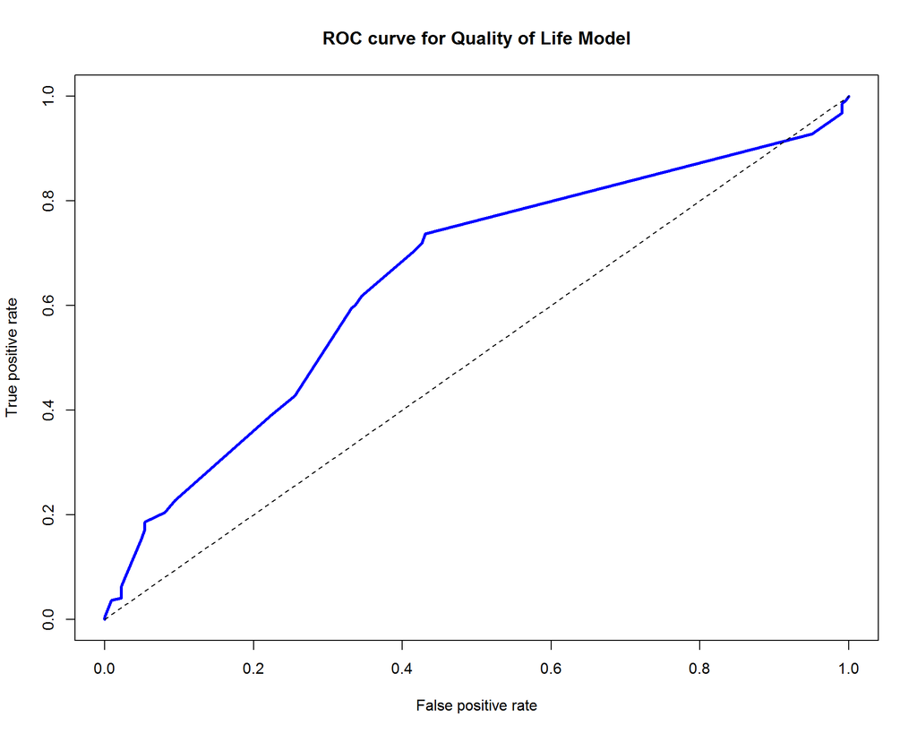

```r
plot(roc, main="ROC curve for Quality of Life Model", col="blue", lwd=3)
segments(0, 0, 1, 1, lty=2)
```

The *segments* command draws the dash line representing a classifier with no predictive value.

To measure the model performance quantitatively we need to create a new performance object with `measure="auc"`, for area under the curve.

```r
roc_auc<-performance(pred, measure="auc")
```

Now the `roc_auc` is stored as a [S4 object](http://adv-r.had.co.nz/OO-essentials.html). This is quite different than data frame and matrices. First, we can use `str()` function to see its structure.

```r
str(roc_auc)
```

```
## Formal class 'performance' [package "ROCR"] with 6 slots
##   ..@ x.name      : chr "None"
##   ..@ y.name      : chr "Area under the ROC curve"
##   ..@ alpha.name  : chr "none"
##   ..@ x.values    : list()
##   ..@ y.values    :List of 1
##   .. ..$ : num 0.65
##   ..@ alpha.values: list()
```

It has 6 members, or “slots”. The AUC value is stored in `y.values`. To extract that we use `@` symbol according to `str()` output.

```r
roc_auc@y.values
```

```
## [[1]]
## [1] 0.6496739
```

# 4 Estimating future performance (internal statistical validation)

The evaluation method we have talked about are all measuring re-substitution error. That is building the model on training data and measuring the model error on test data. This is one way of dealing with unseen data. Let’s look at some alternative strategies.

## 4.1 The holdout method

The `holdout` method idea is to partition a dataset into two separate sets. Using the first set to create (train) the model and the other to test (validate) the model performance. In practice, we usually use a fraction (e.g., $50\%$, or $\frac{2}{3}$) of our data for training the model, and reserve the rest (e.g., $50\%$, or $\frac{1}{3}$) for testing. Note that the testing data may also be further split into proportions for internal repeated (e.g., cross-validation) testing and final external (independent) testing.

The partition has to be randomized. In R, the best way of doing this is to create a parameter that randomly draws numbers and use this parameter to extract random rows from the original dataset. In [Chapter 10](http://www.socr.umich.edu/people/dinov/courses/DSPA_notes/10_ML_NN_SVM_Class.html), we used this method to partition the *Google Trends* data.

Another way of partition is using `caret::createDatePartition()` method. We can subset the original dataset or any independent variable column of the original dataset, e.g., `google_norm$RealEstate`:

```r
sub<-caret::createDataPartition(google_norm$RealEstate, p=0.75, list = F)
google_train<-google_norm[sub, ]
google_test<-google_norm[-sub, ]
```

To make sure that the model can be applied to future datasets, we can partition the original dataset into three separate subsets. In this way, we have two subsets of data for testing and validation. The additional validation dataset can alleviate the probability that we have a good model due to chance (non-representative subsets). A common split among training, testing, and validation subsets may be 50%, 25%, and 25% respectively.

```r
sub<-sample(nrow(google_norm), floor(nrow(google_norm)*0.50))
google_train<-google_norm[sub, ]
google_test<-google_norm[-sub, ]
sub1<-sample(nrow(google_test), floor(nrow(google_test)*0.5))
google_test1<-google_test[sub1, ]
google_test2<-google_test[-sub1, ]
nrow(google_norm)
```

```
## [1] 731
```

```r
nrow(google_train) # training
```

```
## [1] 365
```

```r
nrow(google_test1) # testing: internal cross validation
```

```
## [1] 183
```

```r
nrow(google_test2) # testing: out of bag validation
```

```
## [1] 183
```

However, when we only have a very small dataset, it’s difficult to split off too much data as this may reduce excessively the training sample size. There are the following two options for evaluation of model performance with unseen data. Both of these are implemented in the `caret` package.

## 4.2 Cross-validation

For complete details see the [DSPA Cross-Validation (Chapter 20)](http://www.socr.umich.edu/people/dinov/courses/DSPA_notes/20_PredictionCrossValidation.html). Below, we describe the fundamentals of cross-validation as an internal statistical validation technique.

This technique is known as *k-fold cross-validation* or *k-fold CV*, which is a standard for estimating model performance. K-fold CV randomly partitions the original data into *k* separate random subsets called folds.

A common practice is to use `k=10` or 10-fold CV. That is to split the data into 10 different subsets. Each time, one of the subsets is reserved for testing, and the rest are employed for learning/building the model. This can be accomplished using the `caret::createFolds()` method. Using `seet.seed()` insures the reproducibility of the created folds, in case you run the code multiple times. Here, we use `1234`, a random number, to seed the folds separation. You can use any number for `set.seed()`. We demonstrate the process using the normalized Google Trend dataset.

```r
library("caret")
set.seed(1234)
folds<-createFolds(google_norm$RealEstate, k=10)
str(folds)
```

```
## List of 10
##  $ Fold01: int [1:73] 5 9 11 12 18 19 28 29 54 65 ...
##  $ Fold02: int [1:73] 14 24 35 49 52 61 63 76 99 115 ...
##  $ Fold03: int [1:73] 1 8 41 45 51 74 78 92 100 104 ...
##  $ Fold04: int [1:73] 30 32 37 40 43 57 59 64 70 96 ...
##  $ Fold05: int [1:73] 13 16 25 53 56 68 77 81 93 95 ...
##  $ Fold06: int [1:73] 4 6 15 20 36 69 71 73 79 89 ...
##  $ Fold07: int [1:73] 34 42 44 84 90 98 102 110 112 117 ...
##  $ Fold08: int [1:73] 2 3 48 62 82 85 86 87 88 91 ...
##  $ Fold09: int [1:74] 10 21 23 27 33 39 46 55 58 75 ...
##  $ Fold10: int [1:73] 7 17 22 26 31 38 47 50 60 66 ...
```

Another way to cross-validate is to use `sparsediscrim::cv_partition()` or `caret::createFolds()`.

```r
# install.packages("sparsediscrim")
library(sparsediscrim)
folds2 = cv_partition(1:nrow(google_norm), num_folds=10)
```

And the structure of folds may be reported by:

```r
str(folds2)
```

```
## List of 10
##  $ Fold1 :List of 2
##   ..$ training: int [1:657] 4 5 6 8 9 10 11 12 16 17 ...
##   ..$ test    : int [1:74] 287 3 596 1 722 351 623 257 568 414 ...
##  $ Fold2 :List of 2
##   ..$ training: int [1:658] 1 2 3 5 6 7 8 9 10 11 ...
##   ..$ test    : int [1:73] 611 416 52 203 359 195 452 258 614 121 ...
##  $ Fold3 :List of 2
##   ..$ training: int [1:658] 1 2 3 4 5 7 8 9 10 11 ...
##   ..$ test    : int [1:73] 182 202 443 152 486 229 88 158 178 293 ...
##  $ Fold4 :List of 2
##   ..$ training: int [1:658] 1 2 3 4 5 6 7 8 9 10 ...
##   ..$ test    : int [1:73] 646 439 362 481 183 387 252 520 438 586 ...
##  $ Fold5 :List of 2
##   ..$ training: int [1:658] 1 2 3 4 5 6 7 8 9 10 ...
##   ..$ test    : int [1:73] 503 665 47 603 348 125 719 11 461 361 ...
##  $ Fold6 :List of 2
##   ..$ training: int [1:658] 1 2 3 4 6 7 9 10 11 12 ...
##   ..$ test    : int [1:73] 666 411 159 21 565 298 537 262 131 600 ...
##  $ Fold7 :List of 2
##   ..$ training: int [1:658] 1 2 3 4 5 6 7 8 9 10 ...
##   ..$ test    : int [1:73] 269 572 410 488 124 447 313 255 360 473 ...
##  $ Fold8 :List of 2
##   ..$ training: int [1:658] 1 2 3 4 5 6 7 8 9 11 ...
##   ..$ test    : int [1:73] 446 215 256 116 592 284 294 300 402 455 ...
##  $ Fold9 :List of 2
##   ..$ training: int [1:658] 1 2 3 4 5 6 7 8 9 10 ...
##   ..$ test    : int [1:73] 25 634 717 545 76 378 53 194 70 346 ...
##  $ Fold10:List of 2
##   ..$ training: int [1:658] 1 2 3 4 5 6 7 8 10 11 ...
##   ..$ test    : int [1:73] 468 609 40 101 595 132 248 524 376 618 ...
```

Now, we have 10 different subsets in the `folds` object. We can use `lapply()` to fit the model. 90% of data will be used for training so we use `[-x, ]` to represent all observations not in a specific fold. In [Chapter 10](http://www.socr.umich.edu/people/dinov/courses/DSPA_notes/10_ML_NN_SVM_Class.html) we showed building a neutral network model for the *Google Trends* data. We can do the same for each fold manually. Then we can train, test, and aggregate the results. Finally, we can report the agreement (e.g., correlations between the predicted and observed RealEstate values).

```r
library(neuralnet)
fold_cv<-lapply(folds, function(x){
  google_train<-google_norm[-x, ]
  google_test<-google_norm[x, ]
  google_model<-neuralnet(RealEstate~Unemployment+Rental+Mortgage+Jobs+Investing+DJI_Index+StdDJI, data=google_train)
  google_pred<-compute(google_model, google_test[, c(1:2, 4:8)])
  pred_results<-google_pred$net.result
  pred_cor<-cor(google_test$RealEstate, pred_results)
  return(pred_cor)
  })
str(fold_cv)
```

```
## List of 10
##  $ Fold01: num [1, 1] 0.977
##  $ Fold02: num [1, 1] 0.97
##  $ Fold03: num [1, 1] 0.972
##  $ Fold04: num [1, 1] 0.979
##  $ Fold05: num [1, 1] 0.976
##  $ Fold06: num [1, 1] 0.974
##  $ Fold07: num [1, 1] 0.971
##  $ Fold08: num [1, 1] 0.982
##  $ Fold09: num [1, 1] -0.516
##  $ Fold10: num [1, 1] 0.974
```

From the output, we know that in most of the folds the model predicts very well. In a typical run, one fold may yield bad results. We can use the *mean* of these 10 correlations to represent the *overall* model performance. But first, we need to use `unlist()` function to transform `fold_cv` into a vector.

```r
mean(unlist(fold_cv))
```

```
## [1] 0.8258223801
```

This correlation is high suggesting strong association between predicted and true values. Thus, the model is very good in terms of its prediction.

## 4.3 Bootstrap sampling

The second method is called *bootstrap sampling*. In k-fold CV, each observation can only be used once for testing. Bootstrap sampling relies on a sampling *with replacement* process. Before selecting a new sample, it recycles every observation so that each observation could be appear in multiple folds.

A very special setting of bootstrap uses at each iteration 63.2% of the original data as our training dataset and the remaining 36.8% as the test dataset. Thus, compared to k-fold CV, bootstrap sampling is less representative of the full dataset. A special case of bootstrapping is the *0.632 bootstrap* technique which address this issue with changing the final performance error assessment formula to:

$$error=0.632\times error_{test}+0.368\times error_{train}.$$
This synthesizes the *optimistic model performance* on training data ($error_{train}$) with the *pessimistic model performance* on testing data ($error_{test}$) by weighting the corresponding errors. This method is extremely reliable for small samples (it may be computationally intensive for large samples).

To see the (asymptotics) rationale behind *0.632 bootstrap* technique, consider a standard training set $T$ of cardinality $n$ where our bootstrapping sampling generates $m$ new training sets $T_i$, each of size $n'$. As sampling from $T$ is uniform *with replacement*, some observations may be repeated in each sample $T_i$. Suppose the size of the sub-samples are of the same order as $T$, i.e., $n'=n$, then for large $n$ the sample $T_{i}$ is *expected* to have $\left (1 - \frac{1}{e}\right ) \sim 0.632$ unique cases from the complete original collection $T$, the remaining proportion $0.368$ are expected to be repeated duplicates. Hence the name *0.632 bootstrap* sampling. A particular training data element has a probability of $1-\frac{1}{n}$ of not being picked for training, and hence, its probability of being in the testing set is $\left (1- \frac{1}{n}\right )^n=e^{-1} \sim 0.368$.

The simulation below illustrates the *0.632* bootstrap experimentally:

```r
# define the total data size
n <- 500
# define number of Bootstrap iterations
N=2000
#define the resampling function and compute the proportion of uniquely selected elements
uniqueProportions <- function(myDataSet, sampleSize){
    indices <- sample(1:sampleSize, sampleSize, replace=TRUE) # sample With Replacement
    length(unique(indices))/sampleSize
}
# compute the N proportions of unique elements (could also use a for loop)
proportionsVector <- c(lapply(1:N, uniqueProportions, sampleSize=n), recursive=TRUE)
# report the Expected (mean) proportion of unique elements in the bootstraping samples of n
mean(proportionsVector)
```

```
## [1] 0.632835
```

In general, for large $n\gg n'$, the sample $T_{i}$ is *expected* to have $n\left ( 1-e^{-n'/n}\right )$ unique cases, see [On Estimating the Size and Confidence of a Statistical Audit](http://people.csail.mit.edu/rivest/pubs/APR07.pdf)).

Having the bootstrap samples, the $m$ models can be fitted (estimated) and aggregated, e.g., by averaging the outputs (for regression) or using voting methods (for classification). We will discuss this more in later [Chapters](http://dspa.predictive.space). Let’s look at the implementation of the `0.632 Bootstrap` technique for the *QoL* case-study.

```r
# Recall: qol_model <- C5.0(qol_train[,-c(40, 41)], qol_train$cd)
# predict lables of testing data
qol_pred<-predict(qol_model, qol_test)
# compute matches and mismatches of Predicted and Observed class labels
predObsEqual <- qol_pred == qol_test$cd
predObsTF <- c(table(predObsEqual)[1], table(predObsEqual)[2]); predObsTF
```

```
## FALSE  TRUE
##   163   280
```

```r
# training error rate
train.err <- as.numeric(predObsTF[1]/(predObsTF[1]+predObsTF[2]))

# testing error rate, leave-one-out Bootstrap (LOOB) Cross-Validation
B <- 10
loob.err <- NULL
N <- dim(qol_test)[1]   # size of test-dataset
for (b in 1:B) {
   bootIndices <- sample(1:N, N*0.9, replace=T)
   train <- qol_test[bootIndices, ]
   qol_modelBS <- C5.0(train[,-c(40, 41)], train$cd)
   inner.err <- NULL

   # for current iteration extract the apporopriate tetsing cases for testing
   i <- (1:length(bootIndices))
   i <- i[is.na(match(i, bootIndices))]
   test <- qol_test[i, ]

   # predict using model at current iteration
   qol_modelBS_pred <- predict(qol_modelBS, test)

   predObsEqual <- qol_modelBS_pred == test$cd
   predObsTF <- c(table(predObsEqual)[1], table(predObsEqual)[2]); predObsTF
   # training error rate
   inner.err <- as.numeric(predObsTF[1]/(predObsTF[1]+predObsTF[2]))
   loob.err <- c(loob.err, mean(inner.err))
}

test.err <- ifelse(is.null(loob.err), NA, mean(loob.err))

# 0.632 Bootstrap error
boot.632 <- 0.368 * train.err + 0.632 * test.err; boot.632
```

```
## [1] 0.41079912
```